# Home Equity Default-RF

# Random Forests

Thankfully we can still utilize the cleaned up data from before. The syntax for building a random forest will look very similar to decision trees since the forest is an amalgamation of 'random' trees

```python
#First, we need to build the function to get the random forest variables later

def getEnsembleTreeVars( ENSTREE, varNames ) :
   importance = ENSTREE.feature_importances_
   index = np.argsort(importance)
   theList = []
   for i in index :
       imp_val = importance[i]
       if imp_val > np.average( ENSTREE.feature_importances_ ) :
           v = int( imp_val / np.max( ENSTREE.feature_importances_ ) * 100 )
           theList.append( ( varNames[i], v ) )
   theList = sorted(theList,key=itemgetter(1),reverse=True)
   return theList
```

```python
#Now let's build the model. We can still utilize the same train/test split
#We can start with 25 decision trees made for the forest

concat = 'RF'

f_model_Forest = RandomForestClassifier( n_estimators = 25)
f_model_Forest = f_model_Forest.fit(X_train, Y_train[TARGET_F])
```

```python
#Now that we've fitted our training data
#let's see how accurate we can predict both training and test data

trainForest = getProbAccuracyScores(concat + "_Train", f_model_Forest, X_train, Y_train[TARGET_F])
testForest = getProbAccuracyScores(concat, f_model_Forest, X_test, Y_test[TARGET_F])
```

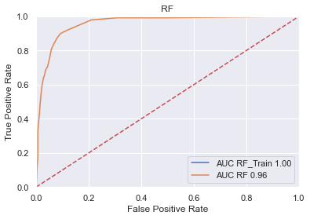

```
RF Classification Accuracy
======
RF_Train  =  0.9995805369127517
RF  =  0.9085570469798657
------
```

```python
#Random Forest Prediction

print_ROC_Curve(concat, [trainForest, testForest])
print_Accuracy(concat + " Classification Accuracy", [trainForest, testForest])
```

```python
#Save these for later to compare tree vs forest and gradient boosting
fpr_forest = fpr_test
tpr_forest = tpr_test
auc_forest = roc_auc_test
```

In line with our amazing results above, we can see the random forests has an AUC of 1, meaning you cannot see it on the chart since it is 1 the entire way on the X & Y axis. Even on the test data, the area under the curve is .96 (or 96%), much higher than just a decision tree.

Finally, let's see which features are accounting for the highest value in our model

```python
#List the features most impactful to our RF model

feature_cos = list(X.columns.values)
vars_RF_flag = getEnsembleTreeVars(f_model_Forest, feature_cols )

temp_df = vars_RF_flag.copy()

vars_RF_flag = []
for i in temp_df:
   vars_RF_flag.append(i[0])

for i in vars_RF_flag:
    print(i)
```

```
M_DEBTINC
TRUNC_IMP_DEBTINC
TRUNC_IMP_CLAGE
TRUNC_IMP_VALUE
TRUNC_IMP_MORTDUE
TRUNC_LOAN
TRUNC_IMP_DELINQ
TRUNC_IMP_CLNO
TRUNC_IMP_YOJ
TRUNC_IMP_DEROG
TRUNC_IMP_NINQ
```

```python
#Same as above, we build a Random Forest model for the loan amount
#Reminder: we have removed outliers in the loan amount above $25000
#We can keep 25 trees as above

a_model_Forest = RandomForestRegressor(n_estimators = 25 )
a_model_Forest = a_model_Forest.fit( W_train, Z_train[TARGET_A] )

Z_Pred_train = a_model_Forest.predict(W_train)
Z_Pred_test = a_model_Forest.predict(W_test)
```

```python
#As a reminder:
#Let's see what the average mean results are for training & testing data
#Note: this is just the average, nothing to do with the model yet

print( "Average Training", Z_train[TARGET_A].mean() )
print( "Average Test", Z_test[TARGET_A].mean() )
```

```
Average Training 12104.263655462184
Average Test 12174.122362869199
```

```python
#Let's run the root mean squaured error (RMSE) to see how close we get

RMSE_Train = math.sqrt( metrics.mean_squared_error(Z_train[TARGET_A], Z_Pred_train))
RMSE_Test = math.sqrt( metrics.mean_squared_error(Z_test[TARGET_A], Z_Pred_test))

print("Random Forest RMSE Training:", RMSE_Train )
print("Random Forest RMSE Test:", RMSE_Test )

#As above, let's save the variable to compare later to forest & boosting
RMSE_Forest = RMSE_Test
```

[output not shown]

```python
#Show which features were used to build the Random Forest

feature_cols = list( X.columns.values )
vars_RF_amt = getEnsembleTreeVars( a_model_Forest, feature_cols )

temp_df = vars_RF_amt.copy()

vars_RF_amt = []
for i in temp_df:
   vars_RF_amt.append(i[0])

for i in vars_RF_amt :
   print( i )
```

```
TRUNC_LOAN
TRUNC_IMP_DEBTINC
TRUNC_IMP_CLNO
TRUNC_IMP_CLAGE
M_DEBTINC
```

```python
#Simplifed Get the RF Model

WHO = "RF"

CLM = RandomForestClassifier( n_estimators = 25 )
CLM = CLM.fit( X_train, Y_train[ TARGET_F ] )

TRAIN_CLM = getProbAccuracyScores( WHO + "_Train", CLM, X_train, Y_train[ TARGET_F ] )
TEST_CLM = getProbAccuracyScores( WHO, CLM, X_test, Y_test[ TARGET_F ] )

feature_cols = list( X.columns.values )

# DAMAGES

AMT = RandomForestRegressor(n_estimators = 100, random_state=1)
AMT = AMT.fit( W_train, Z_train[TARGET_A] )

TRAIN_AMT = getAmtAccuracyScores( WHO + "_Train", AMT, W_train, Z_train[TARGET_A] )
TEST_AMT = getAmtAccuracyScores( WHO, AMT, W_test, Z_test[TARGET_A] )

feature_cols = list( X.columns.values )

RF_CLM = TEST_CLM.copy()
RF_AMT = TEST_AMT.copy()
```